# thermal_exp_27_10_2021

## A new interface for the computation of thermal expansion

A new class (*thermal_expansion_class*) has been defined which is an interface to the calculation of thermal expansion by using three different methods.

Let's see how it works. As usual, run an instance of the bm3_thermal_2 module (the example concerns the mineral pyrope):

```python
%matplotlib inline
%run bm3_thermal_2.py
```

```
This is BMx-QM program, version 2.5.0 - 27/10/2021
Run time:  2021-10-28 17:35:22.856883

File quick_start.txt found in the master folder
Input files in 'pyrope' folder

Input file

STATIC
static_new.dat
VOLUME
volume_agosto_2021.dat
FREQ
freq_agosto_2021.dat
EXP
experimental.txt
LO
LO.txt
FITVOL
POLY
725. 773. 16 2.
FU
4 20
SET
0 1 2 3 4 5 6
CP
0. 2. -2. 1. -1. -0.5
ALPHA
0. -2  -1 -0.5
END

-------- End of input file -------

Frequencies corrected for LO-TO splitting

Static BM3 EoS

Bulk Modulus: 173.89 (0.07) GPa
Kp:             4.26 (0.02)
V0:           756.2048 (0.00) A^3
E0:            -1.14182291e+04 (1.89e-06) hartree
```

Make some preliminary calculation of the equation of state; for instance

```python
eos_temp(298.15, prt=False)
```

```
 ** BM3 fit **

EoS at the temperature of 298.15 K

Bulk Modulus: 159.30   (0.13) GPa
Kp:             4.96   (0.03)
V0:           767.5264 (0.006) A^3

Fix status: False
Fit of frequencies is active
Polynomial fit: degree  2
Volume range: 725.00 - 773.00, points=16
```

Set suitable parameters for the calculation of numerical derivatives of the pressure with respect to the temperature. This can be done by using the *adaptive* scheme defined in the *delta_ctrl* driver:

```python
delta_ctrl.adaptive_on()
```

Print a summary of the current parameters and conditions adopted for the calculations:

```python
info.show()
```

```
Current settings and results

Static data            ** min, max volumes: 718.3435, 771.2740; points: 10
Frequency volume range ** min, max volumes: 725.7483, 772.6196; points: 7
Selected freq. sets    ** min, max volumes: 725.7483, 772.6196; points: 7
Frequency sets:           [0, 1, 2, 3, 4, 5, 6]

Fit of frequencies     ** type: poly, degree: 2
                          min, max volumes: 725.0000, 773.0000; points 16

*** Static EoS (BM3) ***
K0: 173.89 GPa, Kp: 4.26, V0: 756.2048 A^3

** BM3 EoS from the last computation, at the temperature of 298.15 K **
K0: 159.30 GPa, Kp: 4.96, V0: 767.5264 A^3
Kp not fixed

No zone center excluded modes
No off center excluded modes

Kieffer model off

Frequencies corrected for LO-TO splitting.


**** Volume driver for volume_dir function ****
Delta: 2.0; degree:  2; left: 2.0; right: 2.0, Kp_fix: True; t_max: 500.00
EoS shift: 0.0; Quad_shrink:  4; T_dump: 0.0; Dump fact.: 1.0, T_last  0.0
Upgrade shift: False

**** Volume driver for volume_from_F function ****
In addition to the attributes set in the parent volume_control_class:
shift: 0.0, flag: False, upgrade_shift: False

**** Numerical T-derivatives driver class (delta_ctrl) ****
Adaptive scheme active:
T_min, T_max:         50.0,  1000.0 K
Delta_min, Delta_max: 10.0,    50.0 K
Degree:        4
N. of points   8
```

Now let's calculate the thermal expansion. The method *thermal_expansion.info* provides some details concerning the different algorithms:

```python
thermal_expansion.info()
```

```
Methods currently implemented

k_alpha_dir: computes alpha from the product K*alpha, through the
             derivative of P with respect to T, at constant V
             At any T and P, K and P are directly computed from
             the Helmholtz free energy function derivatives. No EoS
             is involved at any step;
k_alpha_eos: same as k_alpha_dir, but pressures and bulk moduli
             are computed from an EoS;
alpha_dir:   the computation is perfomed through the derivative
             of the unit cell volume with respect to V; volumes are
             calculated without reference to any EoS, by the function
             volume_dir.
```

The function to be used is *thermal_expansion.compute*:

```python
help(thermal_expansion.compute)
```

```
Help on method compute in module __main__:

compute(tt, pp, method='default', fix=0, prt=False) method of __main__.thermal_expansion_class instance
    Thermal expansion at a specific temperature and pressure

    Args:
        tt: temperature (K)
        pp: pressure    (GPa)
        method: 3 methods are currently implemented ('k_alpha_dir',
                'k_alpha_eos' and 'alpha_dir'); default 'k_alpha_dir'
        fix: relevant for method 'k_alpha_eos' (default 0., Kp not fixed)
        prt: relevant for method 'k_alpha_eos'; it controls printout
             (default False)
```

At T=298.15 and P=0 GPa, the thermal expansion of pyrope is estimated (default method *k_alpha_dir*) to be:

```python
thermal_expansion.compute(298.15, 0, prt=True)
```

```
Thermal expansion: 3.24e-05 (K^-1)
Bulk modulus:      158.06 (GPa)
Volume:            767.5381 (A^3)
```

By the method *k_alpha_eos*, the computation provides:

```python
thermal_expansion.compute(298.15, 0, method='k_alpha_eos', prt=True)
```

```
Thermal expansion: 3.22e-05 K^-1
Bulk modulus:        159.30 GPa
Pressure:              0.00 GPa
Volume:              767.5264 A^3
```

Note that with method **k_alpha_dir**, the computation of bulk modulus in done by the *bulk_modulus_p* function, with the argument *noeos* set to True, and the equilibrium volume is from the *volume_dir* function.

On the contrary, with the method **k_alpha_eos**, bulk modulus and equilibrium volume come from an EoS fit at the select temperature. Pressures at constant volume are computed from the refined EoS at the different temperature in an interval centered on the selected temperature.

The third method **alpha_dir** is the least efficient in term of computing time, but it does not require the estimation of the bulk modulus by whatever method: it computes $\alpha$ as

$$\alpha = \frac{1}{V} \left(\frac{\partial V}{\partial T}\right)_P$$

The volume at each temperature in an interval centered on the wanted temperature, is compute by the *volume_dir* function. In this case, the algorithm provides:

```python
thermal_expansion.compute(298.15, 0, method='alpha_dir', prt=True)
```

```
Thermal expansion: 3.24e-05 K^-1
```

Thermal expansion can also be computed in a range of temperatures, and optionally fitted by a power series whose parameters can be uploaded in the internal thermodynamic database if a phase label is provided. This can be done by using the *compute_serie* method:

```python
help(thermal_expansion.compute_serie)
```

```
Help on method compute_serie in module __main__:

compute_serie(tmin, tmax, pressure=0, nt=0, fit='default', tex='default', title='default', save='default', phase='default', method='default', prt=True, fix=0) method of __main__.thermal_expansion_class instance
    Thermal expansion in a T-range

    Args:
        tmin, tmax: minimum and maximum temperature in the range
        pressure: pressure (GPa); default 0
        nt: number of points in the T-range; if nt=0, the default is chosen (12)
        method: one of the three methods currently implemented
        fit: if True, a power series fit is performed
        phase: if fit is True and a phase name is specified (label), the data
               from the power series fit are loaded in the internal database
        fix: relevant for the method 'k_alpha_eos'; if fix is not 0.,
             Kp is fixed at the specified value
        title: if True, a title of the plot is provided
        tex: if tex is True, laTeX formatting is provided
        prt: relevant for the method 'k_alpha_eos'
        save: if True, the plot is saved in a file

    Note:
        if save is True and method is 'k_alpha_eos', the name of the file
        where the plot is saved is controlled by the plot.name and plot.ext variables.
        The file resolution is controlled by the plot.dpi variable.
        The appropriate parameters can be set by the set_param method
        of the plot instance of the plot_class class (in the plot.py module)

    Example:
        >>> plot.set_param(dpi=200, name='alpha_k_eos_serie')
        >>> thermal_expansion.compute_serie(100, 500, method='k_alpha_eos', save=True)
```

Here the example for pyrope (default method 'k_alpha_dir')

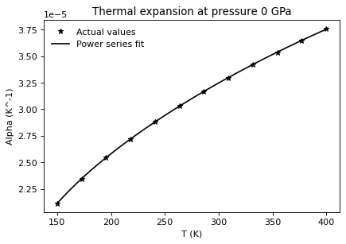

```
Mineral: pyrope

K0: 173.70 GPa, Kp: 4.00, dK0/dT: -0.0261 GPa/K, V0: 11.3180 J/bar
G0: -5934105.00 J/mol, S0: 266.30 J/mol K

EoS type: bm
Cp coefficients and powers:
+6.3350e+02  +0.0
-5.1961e+06  -2.0
-4.3152e+03  -0.5

Alpha coefficients and powers:
+1.0438e-04  +0.0
-3.9410e-01  -2.0
+1.5243e-02  -1.0
-2.0496e-03  -0.5
```

```python
thermal_expansion.compute_serie(150, 400, fit=True, phase='py')
```

Note that, in this case, all of the thermodynamic parameters for pyrope are read from an external database and only the thermal expansion data are upgraded to the new computed values.

By writing a few lines of python code, it is for instance possible to compare the thermal expansion computed through two different algorithms like *k_alpha_dir* and *k_alpha_eos*. The following lines computes the coefficients of the power series from the two methods:

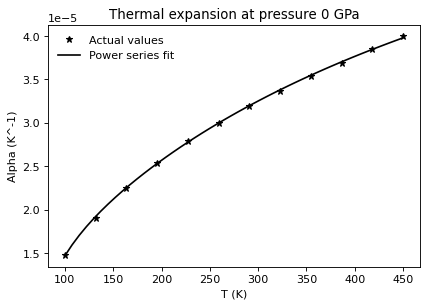

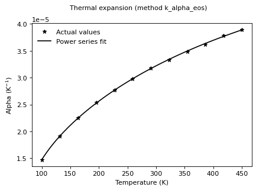

```python
tmin, tmax = 100, 450
alpha_fit1=thermal_expansion.compute_serie(tmin, tmax, fit=True)
alpha_fit2=thermal_expansion.compute_serie(tmin, tmax, method='k_alpha_eos',fit=True)
```

The coefficients of the power series optimized for the two cases are then used to compute $\alpha$ by using the *alpha_fun* function that accepts a list of temperature (*t_list*) and the list of coefficients as arguments:

```python
t_list=np.linspace(tmin, tmax, 50)
alpha_list_1=np.array([alpha_fun(it, *alpha_fit1) for it in t_list])
alpha_list_2=np.array([alpha_fun(it, *alpha_fit2) for it in t_list])
```

The two $\alpha$ curves are then plotted together by using the *plot.multi* method:

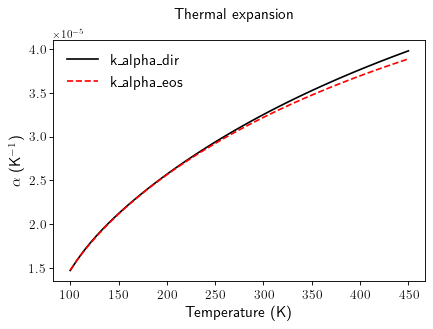

```python
x=[t_list, t_list]
y=[alpha_list_1, alpha_list_2]
style=['k-', 'r--']
label=['k\_alpha\_dir', 'k\_alpha\_eos']
plot.set_param(fsize=14, tsize=12)
plot.multi(x,y,style,label, xlab='Temperature (K)', ylab=r'$\alpha$ (K$^{-1}$)', title='Thermal expansion', tex=True)
```

Use the *help* function to get the: documentation concerning the plotting facilities:

```python
help(plot.multi)
```

```
Help on method multi in module plot:

multi(x, y, sl, lgl, title='', xlab='default', ylab='default', fsize=0, tsize=0, save=False, dpi=0, name='default', ext='default', tex='default') method of plot.plot_class instance
    Plot multiple curves.

    Args:
        x: array of independent variable arrays
        y: array of dependent variable arrays
        sl: array of styles (one for each curve)
        lgl: array of curve labels (for the legend)

    Note:
        See the documentation for the 'simple' method for information
        about the other keyword arguments.

    Example:
        >>> x=np.linspace(-2, 2, 24)
        >>> y1=x**2
        >>> y2=x**3
        >>> x=[x,x]
        >>> y=[y1,y2]
        >>> style=['k-', 'r+']
        >>> label=[r'Y=X$^2$', r'Y=X$^3$']
        >>> plot.multi(x,y, style, label, tex=True)
```

```python
help(plot.simple)
```

```
Help on method simple in module plot:

simple(x, y, title='', style='default', xlab='default', ylab='default', fsize=0, tsize=0, save=False, dpi=0, name='default', ext='default', tex='default') method of plot.plot_class instance
    Plots a single (x, y) curve.

    Args:
        x: independent variable (array of data)
        y: dependent variable (array of data)
        title: plot title (default no title '')
        style: style of the plot (default self.style)
        xlab: X axis label (default self.xlab)
        ylab: Y axis label (default self.ylab)
        fsize: label and title size (default self.fsize)
        tsize: tick size (default self.tsize)
        save: if True, the plot will be saved on a file (default False)
        dpi: resolution of the saved file (default self.dpi)
        name: name of the saved file (default self.name)
        ext: extension (and format) of the saved file (default self.ext)
        tex: if True, tex fonts and format are used

    Note:
        The arguments dpi, name and ext are relevant only if save is True

    Examples:
        >>> plot.simple(x,y, style='r-', xlab='T (K)', ylab='Alpha (K^-1)', fsize=12)

        >>> plot.set_param(fsize=12, style='r-')
        >>> plot.simple(x,y, xlab='T (K)', ylab='alpha (K^-1)')
```